# Analysis of Temperature and Rainfall Trends Using R

**Tiny Project**

**Student:** R Ambarish

**Dataset:** A self-contained 30-day sample weather dataset prepared for academic demonstration.

## 1. Introduction

Weather conditions change from day to day. Temperature and rainfall are two important variables used to understand these changes. This Tiny Project uses R and R Markdown to import, preprocess, analyse and visualize weather data.

## 2. Objectives

- Import weather data from a CSV file.
- Inspect, preprocess and clean the data.
- Calculate descriptive statistics.
- Study temperature and rainfall trends.
- Create graphs and plots.
- Examine the relationship between temperature and rainfall.
- Interpret the results and present findings and a conclusion.

## 3. Data Importing

```
weather <- read.csv("weather_data.csv", stringsAsFactors = FALSE)
weather$Date <- as.Date(weather$Date)
head(weather)
str(weather)
```

**Explanation:** `read.csv()` reads the CSV file. `as.Date()` converts the Date column into proper date format. `head()` displays the first rows and `str()` shows the data structure.

## 4. Data Preprocessing and Cleaning

```
colSums(is.na(weather))
sum(duplicated(weather))

weather <- weather[!duplicated(weather), ]
weather <- weather[complete.cases(weather), ]
```

The dataset is checked for missing values and duplicate rows. Duplicate records and incomplete rows are then removed. In this sample, there are **0** missing cells and **0** duplicate rows before cleaning. The cleaned dataset contains **30** observations.

## 5. Statistical Analysis

```
summary_table <- data.frame(
  Measure = c("Mean", "Median", "Minimum", "Maximum", "Standard Deviation"),
  Temperature_C = c(mean(weather$Temperature_C),
                    median(weather$Temperature_C),
                    min(weather$Temperature_C),
                    max(weather$Temperature_C),
                    sd(weather$Temperature_C)),
  Rainfall_mm = c(mean(weather$Rainfall_mm),
                  median(weather$Rainfall_mm),
                  min(weather$Rainfall_mm),
                  max(weather$Rainfall_mm),
                  sd(weather$Rainfall_mm))
)
knitr::kable(round(summary_table, 2))
```

| Measure | Temperature (°C) | Rainfall (mm) |
| --- | --- | --- |
| Mean | 31.50 | 10.97 |
| Median | 31.50 | 7.00 |
| Minimum | 28.00 | 0.00 |
| Maximum | 36.00 | 35.00 |
| Standard Deviation | 2.21 | 10.76 |

**Explanation:** Mean gives the average, median gives the middle value, minimum and maximum show the range, and standard deviation shows variation.

## 6. Temperature Trend

```
plot(weather$Date, weather$Temperature_C,
     type = "o", pch = 16,
     xlab = "Date", ylab = "Temperature (°C)",
     main = "Daily Temperature Trend")
```

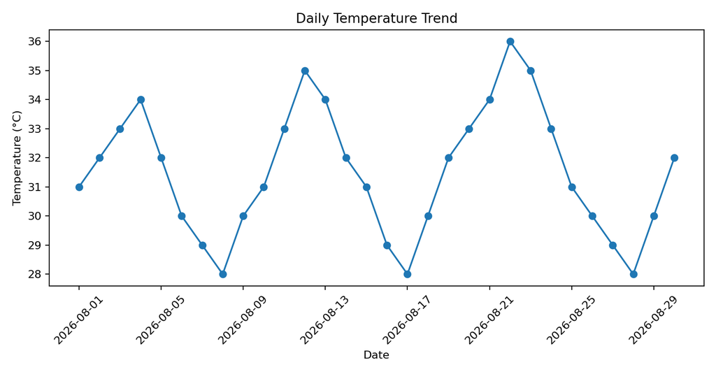

**Interpretation:** The temperature changes across the 30-day period, with both cooler and warmer days.

## 7. Rainfall Trend

```
barplot(weather$Rainfall_mm,
        names.arg = format(weather$Date, "%d"),
        xlab = "Day of August 2026",
        ylab = "Rainfall (mm)",
        main = "Daily Rainfall Trend", las = 2)
```

[figure not shown]

**Interpretation:** Rainfall varies considerably. Several days have little or no rainfall, while a few days have substantially higher rainfall.

## 8. Temperature and Rainfall Relationship

```
plot(weather$Temperature_C, weather$Rainfall_mm,
     pch = 19,
     xlab = "Temperature (°C)",
     ylab = "Rainfall (mm)",
     main = "Temperature vs Rainfall")
abline(lm(Rainfall_mm ~ Temperature_C, data = weather), lty = 2)

cor(weather$Temperature_C, weather$Rainfall_mm)
```

[figure not shown]

**Correlation coefficient:** -0.792

**Interpretation:** The correlation coefficient measures the linear relationship between temperature and rainfall in this sample. It should not be treated as a general climate conclusion because the dataset covers only 30 days.

## 9. Findings

- Average temperature: **31.50 °C**
- Minimum temperature: **28 °C**
- Maximum temperature: **36 °C** on **22-08-2026**
- Average daily rainfall: **10.97 mm**
- Total rainfall: **329 mm**
- Highest rainfall: **35 mm** on **16-08-2026**
- Temperature-rainfall correlation: **-0.792**

## 10. Conclusion

This project demonstrates a complete basic data-analysis workflow in R. The dataset was imported from a CSV file, checked for missing and duplicate records, cleaned, statistically analysed and visualized.

The graphs show that both temperature and rainfall change from day to day. The correlation analysis provides a numerical measure of their linear relationship for the selected sample.

Because this is a small academic dataset covering only 30 days, the findings should not be interpreted as long-term climate behaviour. A larger dataset covering several months or years would be more suitable for long-term weather trend analysis.

## 11. R Functions Used

| Function | Purpose |
| --- | --- |
| `read.csv()` | Imports CSV data |
| `as.Date()` | Converts text to date format |
| `head()` | Displays first rows |
| `str()` | Shows data structure |
| `is.na()` | Checks missing values |
| `duplicated()` | Checks duplicate rows |
| `complete.cases()` | Identifies complete records |
| `mean()`, `median()` | Calculate descriptive statistics |
| `min()`, `max()` | Find minimum and maximum |
| `sd()` | Calculates standard deviation |
| `plot()` | Creates line/scatter plots |
| `barplot()` | Creates a bar graph |
| `cor()` | Calculates correlation |
| `lm()` | Fits a linear model |
| `knitr::kable()` | Creates a formatted table |

## 12. Final Result

The project covers **data importing, preprocessing and cleaning, statistical analysis, graph creation, interpretation, R-code explanation, findings and conclusion** required for the Tiny Project.